# 🏎️ Cars

Erick Marroquín

2026-03-06

```r
library(corrplot)
library(caret)
library(lmtest)
```

## 1. Descripción del Dataset

Utilizaremos el dataset **mtcars**, incluido en R.

Este conjunto contiene información técnica de 32 automóviles, incluyendo variables relacionadas con desempeño del motor y eficiencia.

Variable de interés:

- **mpg**: millas por galón (consumo de combustible) → variable continua.

Algunas variables relevantes:

- wt: peso del vehículo (en miles de libras)
- hp: caballos de fuerza
- disp: desplazamiento del motor
- cyl: número de cilindros

Pregunta de investigación:

> ¿Qué variables explican el consumo de combustible (mpg)?

## 2. Repaso de Regresión Lineal

La regresión lineal modela la relación entre una variable dependiente continua (Y) y una o más variables independientes (X).

Modelo simple:

$$Y = \beta_0 + \beta_1 X +
\varepsilon$$

Modelo múltiple:

$$Y = \beta_0 + \beta_1 X_1 + \beta_2 X_2
+ ... + \beta_k X_k + \varepsilon$$

Supuestos principales:

1. Linealidad
2. Independencia de errores
3. Homocedasticidad
4. Normalidad de residuos

## 3. Análisis Exploratorio

```r
data(mtcars)
df <- mtcars

str(df)
```

```
## 'data.frame':    32 obs. of  11 variables:
##  $ mpg : num  21 21 22.8 21.4 18.7 18.1 14.3 24.4 22.8 19.2 ...
##  $ cyl : num  6 6 4 6 8 6 8 4 4 6 ...
##  $ disp: num  160 160 108 258 360 ...
##  $ hp  : num  110 110 93 110 175 105 245 62 95 123 ...
##  $ drat: num  3.9 3.9 3.85 3.08 3.15 2.76 3.21 3.69 3.92 3.92 ...
##  $ wt  : num  2.62 2.88 2.32 3.21 3.44 ...
##  $ qsec: num  16.5 17 18.6 19.4 17 ...
##  $ vs  : num  0 0 1 1 0 1 0 1 1 1 ...
##  $ am  : num  1 1 1 0 0 0 0 0 0 0 ...
##  $ gear: num  4 4 4 3 3 3 3 4 4 4 ...
##  $ carb: num  4 4 1 1 2 1 4 2 2 4 ...
```

```r
summary(df)
```

```
##       mpg             cyl             disp             hp
##  Min.   :10.40   Min.   :4.000   Min.   : 71.1   Min.   : 52.0
##  1st Qu.:15.43   1st Qu.:4.000   1st Qu.:120.8   1st Qu.: 96.5
##  Median :19.20   Median :6.000   Median :196.3   Median :123.0
##  Mean   :20.09   Mean   :6.188   Mean   :230.7   Mean   :146.7
##  3rd Qu.:22.80   3rd Qu.:8.000   3rd Qu.:326.0   3rd Qu.:180.0
##  Max.   :33.90   Max.   :8.000   Max.   :472.0   Max.   :335.0
##       drat             wt             qsec             vs
##  Min.   :2.760   Min.   :1.513   Min.   :14.50   Min.   :0.0000
##  1st Qu.:3.080   1st Qu.:2.581   1st Qu.:16.89   1st Qu.:0.0000
##  Median :3.695   Median :3.325   Median :17.71   Median :0.0000
##  Mean   :3.597   Mean   :3.217   Mean   :17.85   Mean   :0.4375
##  3rd Qu.:3.920   3rd Qu.:3.610   3rd Qu.:18.90   3rd Qu.:1.0000
##  Max.   :4.930   Max.   :5.424   Max.   :22.90   Max.   :1.0000
##        am              gear            carb
##  Min.   :0.0000   Min.   :3.000   Min.   :1.000
##  1st Qu.:0.0000   1st Qu.:3.000   1st Qu.:2.000
##  Median :0.0000   Median :4.000   Median :2.000
##  Mean   :0.4062   Mean   :3.688   Mean   :2.812
##  3rd Qu.:1.0000   3rd Qu.:4.000   3rd Qu.:4.000
##  Max.   :1.0000   Max.   :5.000   Max.   :8.000
```

### Matriz de correlación

La matriz de correlación nos permite medir la relación lineal entre todas las variables numéricas del dataset.

```r
cor_matrix <- cor(df)
cor_matrix
```

```
##             mpg        cyl       disp         hp        drat         wt
## mpg   1.0000000 -0.8521620 -0.8475514 -0.7761684  0.68117191 -0.8676594
## cyl  -0.8521620  1.0000000  0.9020329  0.8324475 -0.69993811  0.7824958
## disp -0.8475514  0.9020329  1.0000000  0.7909486 -0.71021393  0.8879799
## hp   -0.7761684  0.8324475  0.7909486  1.0000000 -0.44875912  0.6587479
## drat  0.6811719 -0.6999381 -0.7102139 -0.4487591  1.00000000 -0.7124406
## wt   -0.8676594  0.7824958  0.8879799  0.6587479 -0.71244065  1.0000000
## qsec  0.4186840 -0.5912421 -0.4336979 -0.7082234  0.09120476 -0.1747159
## vs    0.6640389 -0.8108118 -0.7104159 -0.7230967  0.44027846 -0.5549157
## am    0.5998324 -0.5226070 -0.5912270 -0.2432043  0.71271113 -0.6924953
## gear  0.4802848 -0.4926866 -0.5555692 -0.1257043  0.69961013 -0.5832870
## carb -0.5509251  0.5269883  0.3949769  0.7498125 -0.09078980  0.4276059
##             qsec         vs          am       gear        carb
## mpg   0.41868403  0.6640389  0.59983243  0.4802848 -0.55092507
## cyl  -0.59124207 -0.8108118 -0.52260705 -0.4926866  0.52698829
## disp -0.43369788 -0.7104159 -0.59122704 -0.5555692  0.39497686
## hp   -0.70822339 -0.7230967 -0.24320426 -0.1257043  0.74981247
## drat  0.09120476  0.4402785  0.71271113  0.6996101 -0.09078980
## wt   -0.17471588 -0.5549157 -0.69249526 -0.5832870  0.42760594
## qsec  1.00000000  0.7445354 -0.22986086 -0.2126822 -0.65624923
## vs    0.74453544  1.0000000  0.16834512  0.2060233 -0.56960714
## am   -0.22986086  0.1683451  1.00000000  0.7940588  0.05753435
## gear -0.21268223  0.2060233  0.79405876  1.0000000  0.27407284
## carb -0.65624923 -0.5696071  0.05753435  0.2740728  1.00000000
```

Ahora la visualizamos gráficamente para interpretar mejor la magnitud y dirección de las relaciones:

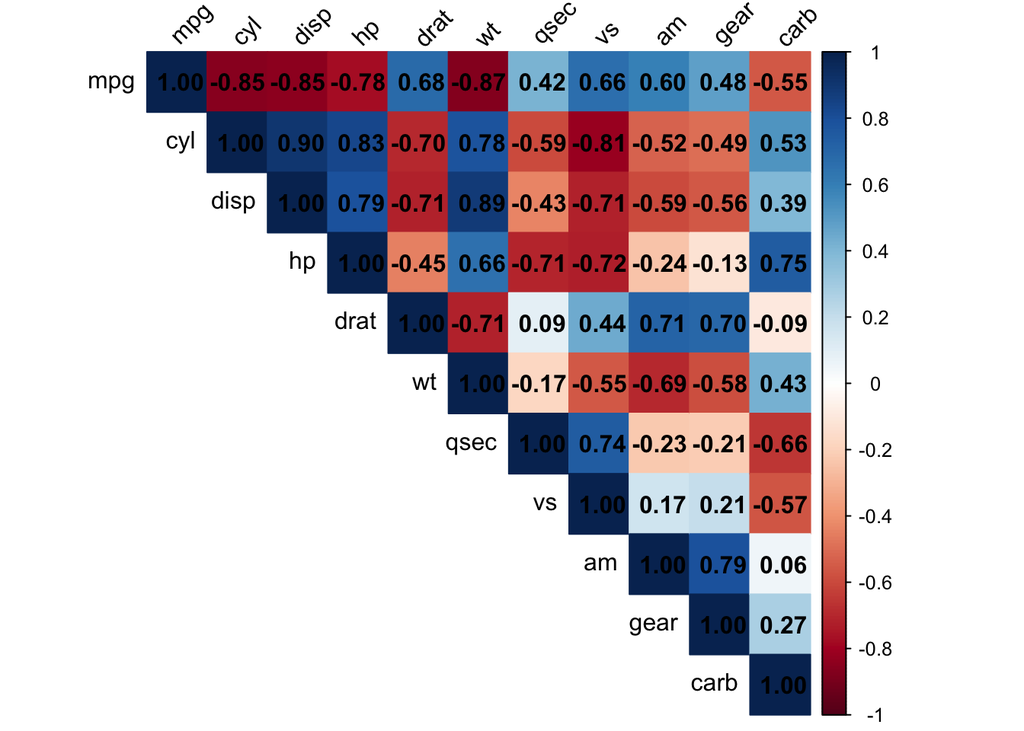

```r
corrplot(cor_matrix, method = "color", type = "upper",
         addCoef.col = "black", tl.col = "black", tl.srt = 45)
```

Interpretación:

- Valores cercanos a 1 → relación positiva fuerte.
- Valores cercanos a -1 → relación negativa fuerte.
- Valores cercanos a 0 → poca o ninguna relación lineal.

Aquí podemos observar que wt y hp tienen correlación negativa considerable con mpg, lo que justifica explorarlas como variables predictoras.

### Scatterplots principales

Los scatterplots nos permiten evaluar visualmente si existe una relación lineal entre la variable respuesta (**mpg**) y posibles variables predictoras.

En esta etapa buscamos:

- Tendencia lineal (creciente o decreciente).
- Presencia de curvatura (posible no linealidad).
- Valores atípicos.
- Dispersión constante (primer indicio de homocedasticidad).

#### mpg vs wt (peso)

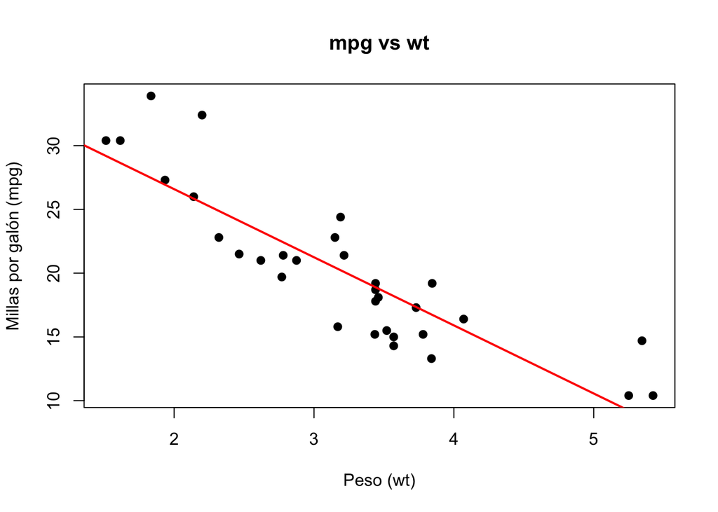

```r
plot(df$wt, df$mpg,
     main="mpg vs wt",
     xlab="Peso (wt)",
     ylab="Millas por galón (mpg)",
     pch=19)
abline(lm(mpg ~ wt, data=df), col="red", lwd=2)
```

Interpretación esperada:

- Relación negativa fuerte.
- A mayor peso, menor eficiencia de combustible.
- Patrón aproximadamente lineal.

#### mpg vs hp (caballos de fuerza)

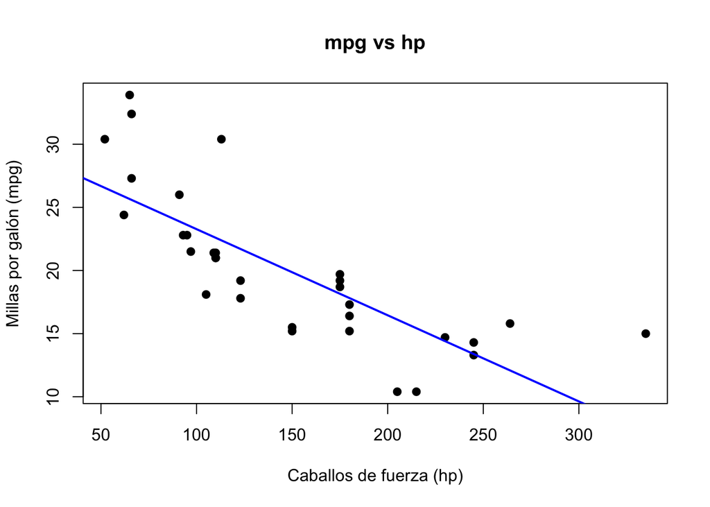

```r
plot(df$hp, df$mpg,
     main="mpg vs hp",
     xlab="Caballos de fuerza (hp)",
     ylab="Millas por galón (mpg)",
     pch=19)
abline(lm(mpg ~ hp, data=df), col="blue", lwd=2)
```

Interpretación esperada:

- Relación negativa moderada a fuerte.
- Vehículos con mayor potencia tienden a consumir más combustible.
- Posible ligera dispersión creciente.

#### mpg vs disp (desplazamiento del motor)

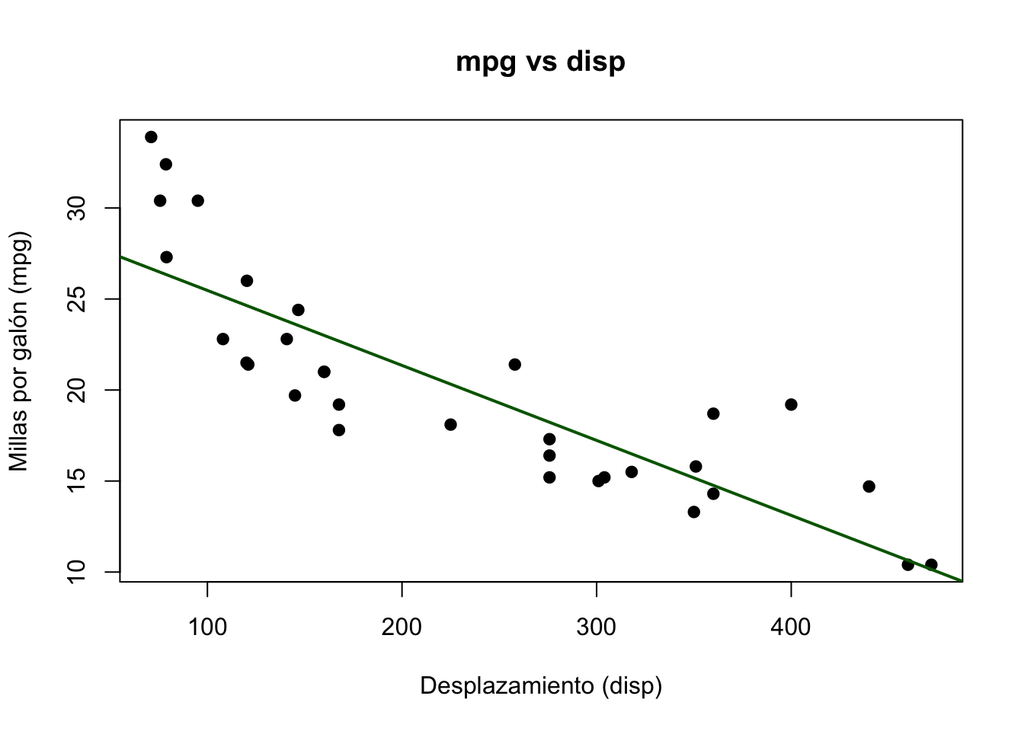

```r
plot(df$disp, df$mpg,
     main="mpg vs disp",
     xlab="Desplazamiento (disp)",
     ylab="Millas por galón (mpg)",
     pch=19)
abline(lm(mpg ~ disp, data=df), col="darkgreen", lwd=2)
```

Interpretación esperada:

- Relación negativa clara.
- Motores más grandes tienden a tener menor rendimiento.

#### mpg vs cyl (número de cilindros)

Aunque es una variable discreta, podemos visualizarla:

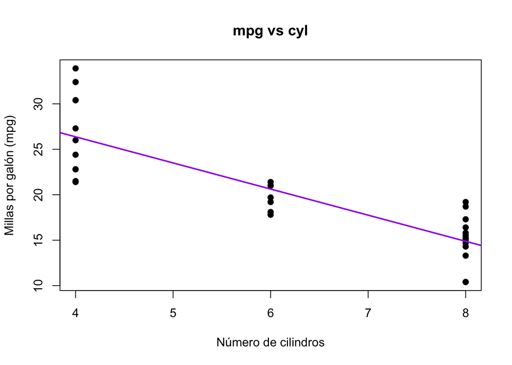

```r
plot(df$cyl, df$mpg,
     main="mpg vs cyl",
     xlab="Número de cilindros",
     ylab="Millas por galón (mpg)",
     pch=19)
abline(lm(mpg ~ cyl, data=df), col="purple", lwd=2)
```

Interpretación:

- Más cilindros → menor mpg.
- Relación escalonada, pero con tendencia lineal negativa.

Conclusión:

Las variables **wt**, **hp** y **disp** muestran patrones lineales negativos claros con **mpg**, lo que justifica su evaluación formal mediante regresión lineal.

Este análisis visual es un paso esencial antes de construir cualquier modelo.

## 4. Selección de Variables

Para realizar un análisis más completo, seleccionaremos tres pares de variables con comportamientos distintos. El objetivo es comparar:

- Un modelo que funciona bien.
- Un modelo que funciona de manera intermedia.
- Un modelo que presenta debilidades claras.

Esto nos permitirá evaluar cómo cambian los supuestos y el desempeño del modelo según la relación entre variables.

### Par 1 — Relación fuerte esperada

**mpg ~ wt**

Justificación:

- `wt` presenta una correlación negativa alta con `mpg`.
- El scatterplot muestra una tendencia lineal clara.
- Teóricamente tiene sentido: vehículos más pesados consumen más combustible.

Esperamos:

- Alto R².
- Supuestos razonablemente bien cumplidos.
- Modelo estable.

### Par 2 — Relación moderada

**mpg ~ hp**

Justificación:

- `hp` también tiene correlación negativa con `mpg`, pero menor que `wt`.
- La dispersión es mayor.
- Puede existir mayor variabilidad no explicada.

Esperamos:

- R² intermedio.
- Mayor dispersión en residuos.
- Posible indicio leve de heterocedasticidad.

### Par 3 — Relación débil o menos adecuada

**mpg ~ qsec** (`qsec` = tiempo en cuarto de milla)

Justificación:

- La relación con `mpg` es más débil.
- El patrón visual no es tan claramente lineal.
- Puede existir mayor ruido y menor capacidad explicativa.

Esperamos:

- Bajo R².
- Mayor incumplimiento de supuestos.
- Residuos con mayor dispersión y posible falta de linealidad.

## 5. Train/Test

Antes de evaluar supuestos y validar modelos, es fundamental separar los datos en entrenamiento y prueba.

¿Por qué es importante?

- Evita evaluar el modelo con los mismos datos usados para ajustarlo.
- Permite medir capacidad predictiva real.
- Reduce riesgo de sobreajuste.

```r
set.seed(314159)

trainIndex <- createDataPartition(df$mpg, p = 0.7, list = FALSE)
train <- df[trainIndex, ]
test  <- df[-trainIndex, ]
```

A partir de ahora, los modelos se ajustarán con `train`.

## 6. Pruebas de Supuestos

Ajustamos los tres modelos en datos de entrenamiento:

```r
model_wt   <- lm(mpg ~ wt, data=train)
model_hp   <- lm(mpg ~ hp, data=train)
model_qsec <- lm(mpg ~ qsec, data=train)
```

### 6.1 Linealidad

Supuesto: la relación entre X y Y debe ser lineal.

Si la relación real no es lineal, el modelo estará mal especificado y los coeficientes serán sesgados.

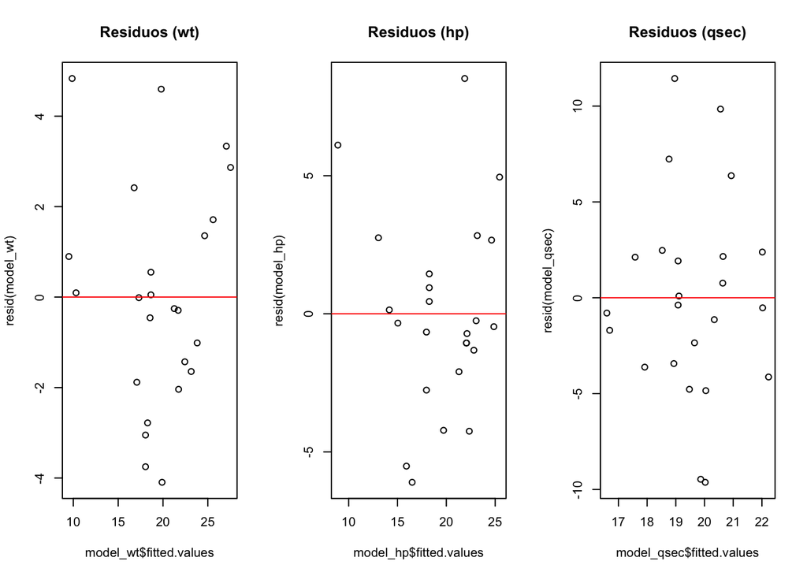

```r
par(mfrow=c(1,3))
plot(model_wt$fitted.values, resid(model_wt), main="Residuos (wt)")
abline(h=0,col="red")

plot(model_hp$fitted.values, resid(model_hp), main="Residuos (hp)")
abline(h=0,col="red")

plot(model_qsec$fitted.values, resid(model_qsec), main="Residuos (qsec)")
abline(h=0,col="red")
```

```r
par(mfrow=c(1,1))
```

Buscamos ausencia de patrones o curvaturas. No hay una prueba estándar para validar linealidad.

### 6.2 Normalidad de Residuos

Supuesto: los errores deben distribuirse normalmente.

La normalidad permite realizar inferencia estadística válida (intervalos y pruebas t).

```r
shapiro.test(resid(model_wt))
```

```
##
##  Shapiro-Wilk normality test
##
## data:  resid(model_wt)
## W = 0.97406, p-value = 0.7667
```

```r
shapiro.test(resid(model_hp))
```

```
##
##  Shapiro-Wilk normality test
##
## data:  resid(model_hp)
## W = 0.96527, p-value = 0.5528
```

```r
shapiro.test(resid(model_qsec))
```

```
##
##  Shapiro-Wilk normality test
##
## data:  resid(model_qsec)
## W = 0.96422, p-value = 0.5288
```

Hipótesis:

- H₀: Los residuos siguen una distribución normal.
- H₁: Los residuos no siguen una distribución normal.

Regla de decisión:

- Si p-value > 0.05 → No se rechaza H₀ (normalidad plausible).
- Si p-value ≤ 0.05 → Se rechaza H₀ (evidencia de no normalidad).

### 6.3 Homocedasticidad

Supuesto: la varianza de los errores debe ser constante.

Si existe heterocedasticidad, los errores estándar serán incorrectos y la inferencia será poco confiable. Prueba Breusch-Pagan.

```r
bptest(model_wt)
```

```
##
##  studentized Breusch-Pagan test
##
## data:  model_wt
## BP = 0.32684, df = 1, p-value = 0.5675
```

```r
bptest(model_hp)
```

```
##
##  studentized Breusch-Pagan test
##
## data:  model_hp
## BP = 0.48366, df = 1, p-value = 0.4868
```

```r
bptest(model_qsec)
```

```
##
##  studentized Breusch-Pagan test
##
## data:  model_qsec
## BP = 0.19106, df = 1, p-value = 0.662
```

Hipótesis:

- H₀: La varianza de los errores es constante (homocedasticidad).
- H₁: La varianza de los errores no es constante (heterocedasticidad).

Regla de decisión:

- Si p-value > 0.05 → No se rechaza H₀ (varianza constante).
- Si p-value ≤ 0.05 → Se rechaza H₀ (existe heterocedasticidad).

### 6.4 Independencia

Supuesto: los errores deben ser independientes.

La autocorrelación genera estimaciones ineficientes. Prueba Durbin-Watson

```r
dwtest(model_wt)
```

```
##
##  Durbin-Watson test
##
## data:  model_wt
## DW = 1.7751, p-value = 0.2533
## alternative hypothesis: true autocorrelation is greater than 0
```

```r
dwtest(model_hp)
```

```
##
##  Durbin-Watson test
##
## data:  model_hp
## DW = 1.178, p-value = 0.01567
## alternative hypothesis: true autocorrelation is greater than 0
```

```r
dwtest(model_qsec)
```

```
##
##  Durbin-Watson test
##
## data:  model_qsec
## DW = 1.1176, p-value = 0.008923
## alternative hypothesis: true autocorrelation is greater than 0
```

Hipótesis:

- H₀: No existe autocorrelación de primer orden en los residuos.
- H₁: Existe autocorrelación de primer orden en los residuos.

Regla de decisión:

- Si p-value > 0.05 → No se rechaza H₀ (independencia plausible).
- Si p-value ≤ 0.05 → Se rechaza H₀ (evidencia de autocorrelación).

## 7. Construcción del Modelo

Comparamos desempeño en entrenamiento:

```r
summary(model_wt)
```

```
##
## Call:
## lm(formula = mpg ~ wt, data = train)
##
## Residuals:
##    Min     1Q Median     3Q    Max
## -4.095 -1.705 -0.134  1.445  4.833
##
## Coefficients:
##             Estimate Std. Error t value Pr(>|t|)
## (Intercept)  34.5099     1.6819  20.518 7.80e-16 ***
## wt           -4.6104     0.4946  -9.321 4.27e-09 ***
## ---
## Signif. codes:  0 '***' 0.001 '**' 0.01 '*' 0.05 '.' 0.1 ' ' 1
##
## Residual standard error: 2.498 on 22 degrees of freedom
## Multiple R-squared:  0.7979, Adjusted R-squared:  0.7887
## F-statistic: 86.87 on 1 and 22 DF,  p-value: 4.273e-09
```

```r
summary(model_hp)
```

```
##
## Call:
## lm(formula = mpg ~ hp, data = train)
##
## Residuals:
##     Min      1Q  Median      3Q     Max
## -6.0992 -1.5127 -0.4011  1.7513  8.5181
##
## Coefficients:
##             Estimate Std. Error t value Pr(>|t|)
## (Intercept) 28.49316    1.75654  16.221 1.01e-13 ***
## hp          -0.05851    0.01048  -5.584 1.30e-05 ***
## ---
## Signif. codes:  0 '***' 0.001 '**' 0.01 '*' 0.05 '.' 0.1 ' ' 1
##
## Residual standard error: 3.574 on 22 degrees of freedom
## Multiple R-squared:  0.5863, Adjusted R-squared:  0.5675
## F-statistic: 31.18 on 1 and 22 DF,  p-value: 1.297e-05
```

```r
summary(model_qsec)
```

```
##
## Call:
## lm(formula = mpg ~ qsec, data = train)
##
## Residuals:
##     Min      1Q  Median      3Q     Max
## -9.6255 -3.4787 -0.4525  2.2117 11.4382
##
## Coefficients:
##             Estimate Std. Error t value Pr(>|t|)
## (Intercept)   2.3165    12.7824   0.181    0.858
## qsec          0.9849     0.7270   1.355    0.189
##
## Residual standard error: 5.339 on 22 degrees of freedom
## Multiple R-squared:  0.077,  Adjusted R-squared:  0.03505
## F-statistic: 1.835 on 1 and 22 DF,  p-value: 0.1892
```

### Información importante

Al revisar `summary()` debemos enfocarnos en los siguientes elementos clave:

#### Coeficientes (Estimate)

Nos indican:

- La **dirección del efecto** (signo positivo o negativo).
- La **magnitud del impacto** sobre `mpg`.

Ejemplo de interpretación:

Si el coeficiente de `wt` es -4.61, significa que:

Por cada aumento de 1 unidad en peso (1000 libras), el mpg disminuye en promedio 4.61 unidades.

Aquí buscamos:

- Coherencia con la teoría.
- Magnitudes razonables.

#### Significancia estadística (Pr(>|t|))

Cada coeficiente prueba:

- H₀: β = 0 (la variable no aporta información)
- H₁: β ≠ 0

Si p-value < 0.05 → la variable es estadísticamente significativa.

Nos interesa identificar:

- Qué variables realmente aportan explicación.
- Cuáles podrían eliminarse del modelo.

#### R² y R² Ajustado

- **R²:** proporción de variabilidad explicada por el modelo.
- **R² ajustado:** corrige por número de variables.

Buscamos:

- Modelos con mayor R².
- Que el R² ajustado no disminuya al agregar variables.

Si agregamos una variable y el R² ajustado baja, esa variable no está aportando suficiente información.

#### Residual Standard Error (RSE)

Mide el error promedio de predicción en las mismas unidades de `mpg`.

Más pequeño → mejor capacidad predictiva en entrenamiento.

#### Comparación entre modelos simples

Aquí evaluamos:

- ¿Cuál variable explica más variabilidad?
- ¿Cuál tiene mayor R²?
- ¿Cuál presenta coeficientes más significativos?

Esto nos permite decidir qué variables son candidatas para el modelo múltiple.

Luego construimos un modelo múltiple con las variables más prometedoras:

```r
model_multiple <- lm(mpg ~ wt + hp, data=train)
summary(model_multiple)
```

```
##
## Call:
## lm(formula = mpg ~ wt + hp, data = train)
##
## Residuals:
##    Min     1Q Median     3Q    Max
## -3.152 -1.587 -0.591  1.055  4.526
##
## Coefficients:
##              Estimate Std. Error t value Pr(>|t|)
## (Intercept) 34.893797   1.402478  24.880  < 2e-16 ***
## wt          -3.515191   0.528568  -6.650 1.39e-06 ***
## hp          -0.025788   0.007825  -3.296  0.00345 **
## ---
## Signif. codes:  0 '***' 0.001 '**' 0.01 '*' 0.05 '.' 0.1 ' ' 1
##
## Residual standard error: 2.076 on 21 degrees of freedom
## Multiple R-squared:  0.8668, Adjusted R-squared:  0.8541
## F-statistic: 68.34 on 2 and 21 DF,  p-value: 6.409e-10
```

El modelo estimado es de la forma:

mpg = β₀ + β₁·wt + β₂·hp + ε

Ahora debemos analizar:

*Si ambos coeficientes siguen siendo significativos.* Si el R² ajustado mejora respecto a los modelos simples. *Si alguno pierde significancia (posible multicolinealidad).* Si el error estándar residual disminuye.

## 8. Validación del Modelo

Evaluamos los modelos utilizando el conjunto de prueba (datos no vistos).

```r
pred_wt   <- predict(model_wt, test)
pred_hp   <- predict(model_hp, test)
pred_qsec <- predict(model_qsec, test)
pred_mult <- predict(model_multiple, test)
```

### Métricas de Evaluación

Calculamos RMSE y R² para cada modelo en test.

```r
R2_test <- function(actual, predicted) {
  1 - sum((actual - predicted)^2) / sum((actual - mean(actual))^2)
}

results <- data.frame(
  Modelo = c("mpg ~ wt", "mpg ~ hp", "mpg ~ qsec", "mpg ~ wt + hp"),
  RMSE = c(
    RMSE(pred_wt, test$mpg),
    RMSE(pred_hp, test$mpg),
    RMSE(pred_qsec, test$mpg),
    RMSE(pred_mult, test$mpg)
  ),
  R2 = c(
    R2_test(test$mpg, pred_wt),
    R2_test(test$mpg, pred_hp),
    R2_test(test$mpg, pred_qsec),
    R2_test(test$mpg, pred_mult)
  )
)

results
```

```
##          Modelo     RMSE        R2
## 1      mpg ~ wt 4.507018 0.6137438
## 2      mpg ~ hp 4.762173 0.5687717
## 3    mpg ~ qsec 6.333005 0.2373653
## 4 mpg ~ wt + hp 3.909968 0.7093012
```

Interpretación:

- **RMSE más bajo** → mejor capacidad predictiva.
- **R² más alto** → mayor proporción de variabilidad explicada en datos nuevos.

### Comparación Visual de Modelos

#### Comparación por RMSE

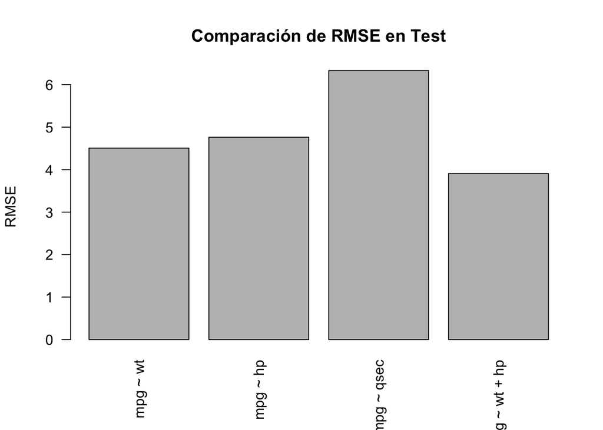

```r
barplot(results$RMSE,
        names.arg = results$Modelo,
        main = "Comparación de RMSE en Test",
        ylab = "RMSE",
        las = 2)
```

#### Comparación por R²

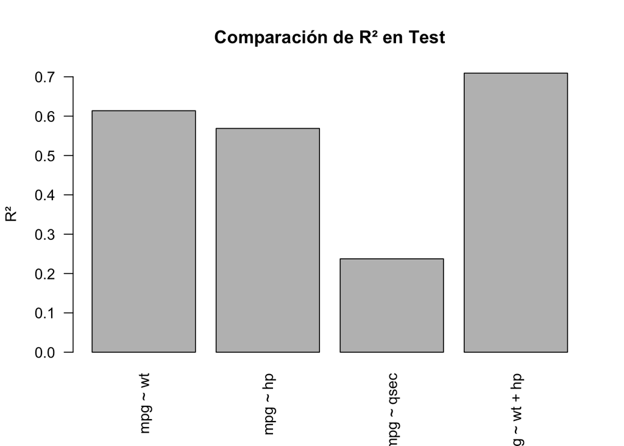

```r
barplot(results$R2,
        names.arg = results$Modelo,
        main = "Comparación de R² en Test",
        ylab = "R²",
        las = 2)
```

El mejor modelo será aquel que combine:

- Menor RMSE.
- Mayor R².
- Coherencia estadística en los supuestos.

La validación en test permite identificar qué modelo realmente generaliza mejor y evita tomar decisiones basadas únicamente en desempeño de entrenamiento.

## 9. Guardar Predicciones en el Dataset (extra)

Agregamos una nueva columna al conjunto de prueba:

```r
test$mpg_predicho <- pred_mult
head(test[, c("mpg", "mpg_predicho")])
```

```
##                 mpg mpg_predicho
## Hornet 4 Drive 21.4     20.75574
## Merc 230       22.8     21.37105
## Merc 280C      17.8     19.62958
## Merc 450SE     16.4     15.94507
## Fiat 128       32.4     25.45835
## Toyota Corolla 33.9     26.76718
```

Ahora el dataset de prueba contiene:

- Valor real (`mpg`)
- Valor predicho (`mpg_predicho`)

Esto permite comparar directamente errores individuales y analizar desempeño a nivel observación.